# Eksplorasi AED Final

# Library

```r
library(tidyverse)
```

```r
library(ggplot2)
library(dplyr)
library(psych)
library(moments)
library(nortest)
library(tidyr)
library(patchwork)
library(FSA)
```

# Impoer Data

```r
data <- read_csv("D:\\Mine\\Kuliah Journey\\Semester 4\\Analisis Eksplorasi Data\\susenas_depok_merged_FIX_FIX.csv")
data
```

```
## # A tibble: 1,037 × 23
##      URUT  R101  R102  R105     FOOD  NONFOOD EXPEND KAPITA KALORI_KAP PROTE_KAP
##     <dbl> <dbl> <dbl> <dbl>    <dbl>    <dbl>  <dbl>  <dbl>      <dbl>     <dbl>
##  1 500091    32    76     1 3712543. 4579733. 8.29e6 4.15e6      1582.      57.8
##  2 500117    32    76     1 1978286. 3228167. 5.21e6 1.30e6      1352.      40.6
##  3 500129    32    76     1 3031286. 4845500  7.88e6 1.97e6      2023.      64.5
##  4 500139    32    76     1 1500000  4308750  5.81e6 5.81e6      3057.     109.
##  5 500170    32    76     1 4943143. 2884000  7.83e6 1.57e6      1556.      49.9
##  6 500172    32    76     1 2692457. 2897125  5.59e6 1.40e6      2257.      60.5
##  7 500174    32    76     1 4994571. 5044500  1.00e7 1.67e6      1687.      53.5
##  8 500192    32    76     1 1834671. 1906667. 3.74e6 9.35e5      1119.      47.0
##  9 500212    32    76     1 2725286. 6233917. 8.96e6 8.96e6      2476.      68.9
## 10 500223    32    76     1 1825500  2870250. 4.70e6 9.39e5      1441.      46.5
## # ℹ 1,027 more rows
## # ℹ 13 more variables: LEMAK_KAP <dbl>, KARBO_KAP <dbl>, R1802 <dbl>,
## #   R1810A <dbl>, R2001B <dbl>, R2001C <dbl>, R2001D <dbl>, R2001F <dbl>,
## #   R2001G <dbl>, R2001H <dbl>, R2001K <dbl>, R2001M <dbl>, Banyak_Anak <dbl>
```

```r
str(data)
```

```
## spc_tbl_ [1,037 × 23] (S3: spec_tbl_df/tbl_df/tbl/data.frame)
##  $ URUT       : num [1:1037] 5e+05 5e+05 5e+05 5e+05 5e+05 ...
##  $ R101       : num [1:1037] 32 32 32 32 32 32 32 32 32 32 ...
##  $ R102       : num [1:1037] 76 76 76 76 76 76 76 76 76 76 ...
##  $ R105       : num [1:1037] 1 1 1 1 1 1 1 1 1 1 ...
##  $ FOOD       : num [1:1037] 3712543 1978286 3031286 1500000 4943143 ...
##  $ NONFOOD    : num [1:1037] 4579733 3228167 4845500 4308750 2884000 ...
##  $ EXPEND     : num [1:1037] 8292276 5206452 7876786 5808750 7827143 ...
##  $ KAPITA     : num [1:1037] 4146138 1301613 1969196 5808750 1565429 ...
##  $ KALORI_KAP : num [1:1037] 1582 1352 2023 3057 1556 ...
##  $ PROTE_KAP  : num [1:1037] 57.8 40.6 64.5 109.1 49.9 ...
##  $ LEMAK_KAP  : num [1:1037] 47.3 28.2 40.5 41.3 40.1 ...
##  $ KARBO_KAP  : num [1:1037] 224 185 296 449 229 ...
##  $ R1802      : num [1:1037] 3 1 1 1 1 1 1 1 1 1 ...
##  $ R1810A     : num [1:1037] 2 4 4 3 2 1 4 2 1 4 ...
##  $ R2001B     : num [1:1037] 5 1 1 1 1 1 1 1 1 1 ...
##  $ R2001C     : num [1:1037] 5 1 1 5 5 5 5 5 5 5 ...
##  $ R2001D     : num [1:1037] 5 5 5 5 5 5 5 5 5 5 ...
##  $ R2001F     : num [1:1037] 5 5 5 5 5 1 5 5 1 1 ...
##  $ R2001G     : num [1:1037] 5 5 1 5 5 5 5 5 5 5 ...
##  $ R2001H     : num [1:1037] 1 1 1 5 1 1 1 1 1 1 ...
##  $ R2001K     : num [1:1037] 5 5 1 1 5 5 5 5 5 5 ...
##  $ R2001M     : num [1:1037] 5 1 1 1 1 1 1 1 1 1 ...
##  $ Banyak_Anak: num [1:1037] 0 2 1 0 3 2 4 2 0 3 ...
##  - attr(*, "spec")=
##   .. cols(
##   ..   URUT = col_double(),
##   ..   R101 = col_double(),
##   ..   R102 = col_double(),
##   ..   R105 = col_double(),
##   ..   FOOD = col_double(),
##   ..   NONFOOD = col_double(),
##   ..   EXPEND = col_double(),
##   ..   KAPITA = col_double(),
##   ..   KALORI_KAP = col_double(),
##   ..   PROTE_KAP = col_double(),
##   ..   LEMAK_KAP = col_double(),
##   ..   KARBO_KAP = col_double(),
##   ..   R1802 = col_double(),
##   ..   R1810A = col_double(),
##   ..   R2001B = col_double(),
##   ..   R2001C = col_double(),
##   ..   R2001D = col_double(),
##   ..   R2001F = col_double(),
##   ..   R2001G = col_double(),
##   ..   R2001H = col_double(),
##   ..   R2001K = col_double(),
##   ..   R2001M = col_double(),
##   ..   Banyak_Anak = col_double()
##   .. )
##  - attr(*, "problems")=<externalptr>
```

```r
summary(data)
```

```
##       URUT             R101         R102         R105        FOOD
##  Min.   :500091   Min.   :32   Min.   :76   Min.   :1   Min.   :  358114
##  1st Qu.:507106   1st Qu.:32   1st Qu.:76   1st Qu.:1   1st Qu.: 2247000
##  Median :514059   Median :32   Median :76   Median :1   Median : 3228000
##  Mean   :513076   Mean   :32   Mean   :76   Mean   :1   Mean   : 4010598
##  3rd Qu.:519007   3rd Qu.:32   3rd Qu.:76   3rd Qu.:1   3rd Qu.: 5096143
##  Max.   :525878   Max.   :32   Max.   :76   Max.   :1   Max.   :26392286
##     NONFOOD             EXPEND             KAPITA           KALORI_KAP
##  Min.   :  444750   Min.   :  883281   Min.   :  383551   Min.   :1009
##  1st Qu.: 2222417   1st Qu.: 4611917   1st Qu.: 1387986   1st Qu.:1757
##  Median : 3849333   Median : 7392825   Median : 2152346   Median :2122
##  Mean   : 6082265   Mean   :10092864   Mean   : 3115970   Mean   :2200
##  3rd Qu.: 7181417   3rd Qu.:12372762   3rd Qu.: 4115251   3rd Qu.:2544
##  Max.   :65162417   Max.   :73103417   Max.   :28683191   Max.   :4450
##    PROTE_KAP        LEMAK_KAP        KARBO_KAP         R1802
##  Min.   : 24.13   Min.   : 17.03   Min.   :121.0   Min.   :1.000
##  1st Qu.: 54.03   1st Qu.: 40.87   1st Qu.:233.7   1st Qu.:1.000
##  Median : 65.73   Median : 51.28   Median :281.5   Median :1.000
##  Mean   : 69.12   Mean   : 54.98   Mean   :293.3   Mean   :1.359
##  3rd Qu.: 80.83   3rd Qu.: 64.18   3rd Qu.:335.4   3rd Qu.:2.000
##  Max.   :181.24   Max.   :249.45   Max.   :681.0   Max.   :4.000
##      R1810A          R2001B          R2001C          R2001D
##  Min.   :1.000   Min.   :1.000   Min.   :1.000   Min.   :1.000
##  1st Qu.:2.000   1st Qu.:1.000   1st Qu.:1.000   1st Qu.:5.000
##  Median :2.000   Median :1.000   Median :5.000   Median :5.000
##  Mean   :2.724   Mean   :1.328   Mean   :3.692   Mean   :4.865
##  3rd Qu.:4.000   3rd Qu.:1.000   3rd Qu.:5.000   3rd Qu.:5.000
##  Max.   :7.000   Max.   :5.000   Max.   :5.000   Max.   :5.000
##      R2001F          R2001G          R2001H          R2001K
##  Min.   :1.000   Min.   :1.000   Min.   :1.000   Min.   :1.000
##  1st Qu.:1.000   1st Qu.:1.000   1st Qu.:1.000   1st Qu.:5.000
##  Median :5.000   Median :5.000   Median :1.000   Median :5.000
##  Mean   :3.276   Mean   :3.827   Mean   :1.656   Mean   :4.182
##  3rd Qu.:5.000   3rd Qu.:5.000   3rd Qu.:1.000   3rd Qu.:5.000
##  Max.   :5.000   Max.   :5.000   Max.   :5.000   Max.   :5.000
##      R2001M       Banyak_Anak
##  Min.   :1.000   Min.   :0.000
##  1st Qu.:1.000   1st Qu.:1.000
##  Median :1.000   Median :2.000
##  Mean   :2.038   Mean   :1.533
##  3rd Qu.:5.000   3rd Qu.:2.000
##  Max.   :5.000   Max.   :6.000
```

```r
describe(data)
```

```
##             vars    n        mean         sd     median    trimmed        mad
## URUT           1 1037   513076.23    7215.59  514059.00  513142.87    8662.83
## R101           2 1037       32.00       0.00      32.00      32.00       0.00
## R102           3 1037       76.00       0.00      76.00      76.00       0.00
## R105           4 1037        1.00       0.00       1.00       1.00       0.00
## FOOD           5 1037  4010598.45 2643133.93 3228000.00 3619323.23 1865534.40
## NONFOOD        6 1037  6082265.29 6729525.45 3849333.33 4711551.86 2904289.85
## EXPEND         7 1037 10092863.74 8889752.29 7392824.76 8419827.64 4812344.51
## KAPITA         8 1037  3115969.62 2655442.87 2152346.43 2660272.47 1587021.52
## KALORI_KAP     9 1037     2199.90     619.17    2122.48    2147.10     578.63
## PROTE_KAP     10 1037       69.12      21.64      65.73      67.27      20.04
## LEMAK_KAP     11 1037       54.98      22.03      51.28      52.53      17.03
## KARBO_KAP     12 1037      293.26      85.82     281.54     286.07      74.92
## R1802         13 1037        1.36       0.65       1.00       1.21       0.00
## R1810A        14 1037        2.72       1.32       2.00       2.74       1.48
## R2001B        15 1037        1.33       1.10       1.00       1.00       0.00
## R2001C        16 1037        3.69       1.88       5.00       3.86       0.00
## R2001D        17 1037        4.86       0.72       5.00       5.00       0.00
## R2001F        18 1037        3.28       1.98       5.00       3.34       0.00
## R2001G        19 1037        3.83       1.82       5.00       4.03       0.00
## R2001H        20 1037        1.66       1.48       1.00       1.32       0.00
## R2001K        21 1037        4.18       1.61       5.00       4.48       0.00
## R2001M        22 1037        2.04       1.75       1.00       1.80       0.00
## Banyak_Anak   23 1037        1.53       1.05       2.00       1.49       1.48
##                   min         max       range  skew kurtosis        se
## URUT        500091.00   525878.00    25787.00 -0.12    -1.08    224.07
## R101            32.00       32.00        0.00   NaN      NaN      0.00
## R102            76.00       76.00        0.00   NaN      NaN      0.00
## R105             1.00        1.00        0.00   NaN      NaN      0.00
## FOOD        358114.29 26392285.71 26034171.43  2.04     7.53  82078.57
## NONFOOD     444750.00 65162416.67 64717666.67  3.34    16.29 208975.35
## EXPEND      883280.95 73103416.67 72220135.71  2.69    10.05 276057.96
## KAPITA      383550.60 28683190.48 28299639.88  2.76    13.95  82460.81
## KALORI_KAP    1008.96     4450.27     3441.30  0.89     0.99     19.23
## PROTE_KAP       24.13      181.24      157.12  1.02     1.84      0.67
## LEMAK_KAP       17.03      249.45      232.41  2.13     9.87      0.68
## KARBO_KAP      121.01      680.98      559.97  0.95     1.42      2.66
## R1802            1.00        4.00        3.00  1.60     1.28      0.02
## R1810A           1.00        7.00        6.00 -0.03    -1.54      0.04
## R2001B           1.00        5.00        4.00  3.04     7.27      0.03
## R2001C           1.00        5.00        4.00 -0.74    -1.46      0.06
## R2001D           1.00        5.00        4.00 -5.16    24.61      0.02
## R2001F           1.00        5.00        4.00 -0.28    -1.92      0.06
## R2001G           1.00        5.00        4.00 -0.91    -1.18      0.06
## R2001H           1.00        5.00        4.00  1.81     1.29      0.05
## R2001K           1.00        5.00        4.00 -1.46     0.14      0.05
## R2001M           1.00        5.00        4.00  1.10    -0.80      0.05
## Banyak_Anak      0.00        6.00        6.00  0.42     0.32      0.03
```

```r
colSums(is.na(data))
```

```
##        URUT        R101        R102        R105        FOOD     NONFOOD
##           0           0           0           0           0           0
##      EXPEND      KAPITA  KALORI_KAP   PROTE_KAP   LEMAK_KAP   KARBO_KAP
##           0           0           0           0           0           0
##       R1802      R1810A      R2001B      R2001C      R2001D      R2001F
##           0           0           0           0           0           0
##      R2001G      R2001H      R2001K      R2001M Banyak_Anak
##           0           0           0           0           0
```

# Sebaran Kapita

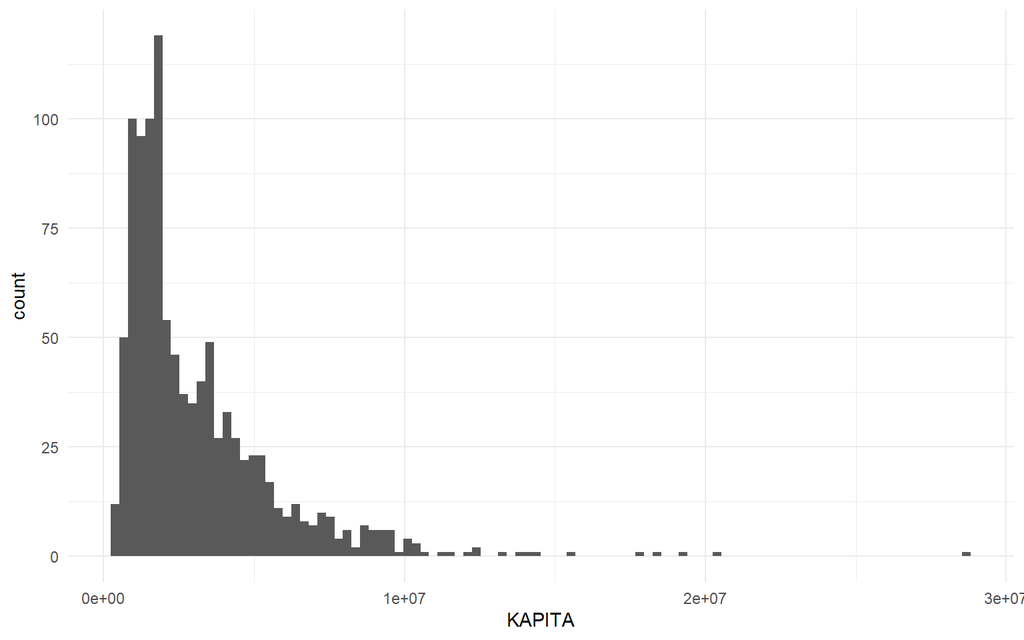

```r
ggplot(data, aes(x = KAPITA)) +
geom_histogram(bins = 100) +
theme_minimal()
```

# Melihat outlier

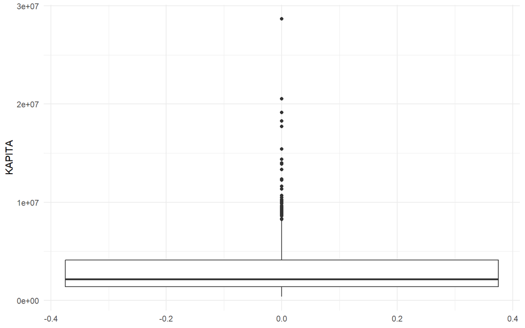

```r
ggplot(data, aes(y = KAPITA)) +
geom_boxplot() +
theme_minimal()
```

# Uji Kolmogorov Smirnov

```r
# Identifikasi variabel numerik
numeric_vars <- names(data)[sapply(data, is.numeric)]

# Membandingkan distribusi data dengan distribusi normal (pnorm)
lakukan_ks <- function(column_name) {
  x <- data[[column_name]]

  # Jika standar deviasi 0, uji tidak bisa dilakukan
  if (sd(x) > 0) {
    test <- ks.test(x, "pnorm", mean(x), sd(x))
    return(data.frame(
      Variable = column_name,
      Statistic = test$statistic,
      p_value = test$p.value,
      Kesimpulan = ifelse(test$p.value > 0.05, "Normal", "Tidak Normal")
    ))
  } else {
    return(NULL)
  }
}

hasil_ks <- do.call(rbind, lapply(numeric_vars, lakukan_ks))
print(hasil_ks)
```

```
##        Variable  Statistic       p_value   Kesimpulan
## D          URUT 0.06584131  2.490630e-04 Tidak Normal
## D1         FOOD 0.12449736  2.188422e-14 Tidak Normal
## D2      NONFOOD 0.20666640  6.762213e-39 Tidak Normal
## D3       EXPEND 0.17764718  7.506286e-29 Tidak Normal
## D4       KAPITA 0.15551082  3.297615e-22 Tidak Normal
## D5   KALORI_KAP 0.06890264  1.058676e-04 Tidak Normal
## D6    PROTE_KAP 0.06774310  1.470552e-04 Tidak Normal
## D7    LEMAK_KAP 0.10726351  8.664701e-11 Tidak Normal
## D8    KARBO_KAP 0.06901729  1.024521e-04 Tidak Normal
## D9        R1802 0.44551390 3.329762e-179 Tidak Normal
## D10      R1810A 0.29584604  2.917609e-79 Tidak Normal
## D11      R2001B 0.53543421 1.179952e-258 Tidak Normal
## D12      R2001C 0.43005843 5.145028e-167 Tidak Normal
## D13      R2001D 0.54034240 2.069781e-263 Tidak Normal
## D14      R2001F 0.37679814 2.622352e-128 Tidak Normal
## D15      R2001G 0.44695773 2.300120e-180 Tidak Normal
## D16      R2001H 0.50703582 5.462621e-232 Tidak Normal
## D17      R2001K 0.48937350 3.883304e-216 Tidak Normal
## D18      R2001M 0.46351942 6.020868e-194 Tidak Normal
## D19 Banyak_Anak 0.19103734  2.683902e-33 Tidak Normal
```

Hasil uji normalitas menggunakan Kolmogorov Smirnov menunjukkan nilai p-value < 0.05 untuk seluruh variabel. Artinya, seluruh variabel tidak berdstribusi normal yang merupakan karakteristik umum pada data survei sosial-ekonomi (Susenas) yang memiliki keragaman tinggi. Oleh karena itu, seluruh pengujian hipotesis dalam penelitian ini dilakukan menggunakan pendekatan statistik non-parametrik.

# Sebaran Kesejahteraan per Kategori Aset

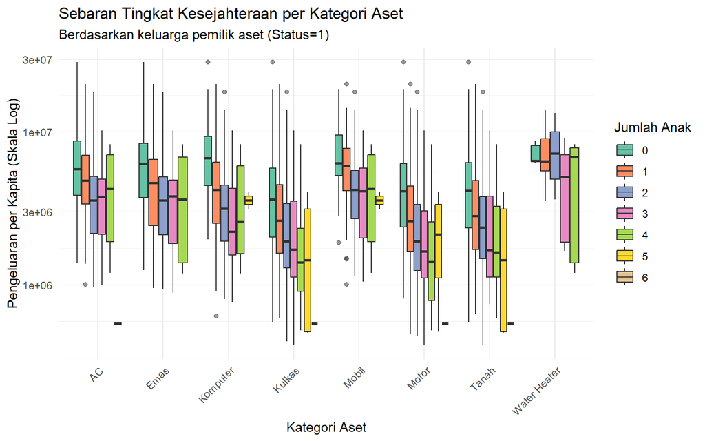

```r
asset_map <- c(
  "R2001B" = "Kulkas",
  "R2001C" = "AC",
  "R2001D" = "Water Heater",
  "R2001F" = "Komputer",
  "R2001G" = "Emas",
  "R2001H" = "Motor",
  "R2001K" = "Mobil",
  "R2001M" = "Tanah"
)

df_long <- data %>%
  filter(Banyak_Anak %in% c(0, 1, 2, 3, 4, 5, 6)) %>%
  # Mengambil kolom identitas dan kolom aset
  select(URUT, Banyak_Anak, KAPITA, all_of(names(asset_map))) %>%
  # Mengubah format menjadi satu kolom 'Kategori' dan satu kolom 'Status'
  pivot_longer(cols = all_of(names(asset_map)),
               names_to = "Asset_Code",
               values_to = "Status") %>%
  # Filter hanya untuk yang memiliki aset (Status == 1)
  filter(Status == 1) %>%
  # Memberi nama kategori yang lebih mudah dibaca
  mutate(Kategori_Aset = asset_map[Asset_Code],
         Banyak_Anak = as.factor(Banyak_Anak))

ggplot(df_long, aes(x = Kategori_Aset, y = KAPITA, fill = Banyak_Anak)) +
  geom_boxplot(outlier.alpha = 0.5) +
  scale_y_log10() + # Menggunakan skala log agar sebaran lebih terlihat jelas
  scale_fill_brewer(palette = "Set2") +
  labs(title = "Sebaran Tingkat Kesejahteraan per Kategori Aset",
       subtitle = "Berdasarkan keluarga pemilik aset (Status=1)",
       x = "Kategori Aset",
       y = "Pengeluaran per Kapita (Skala Log)",
       fill = "Jumlah Anak") +
  theme_minimal() +
  theme(axis.text.x = element_text(angle = 45, hjust = 1))
```

# Perbandingan Porsi Anggaran Makanan (%) vs Jumlah Anak

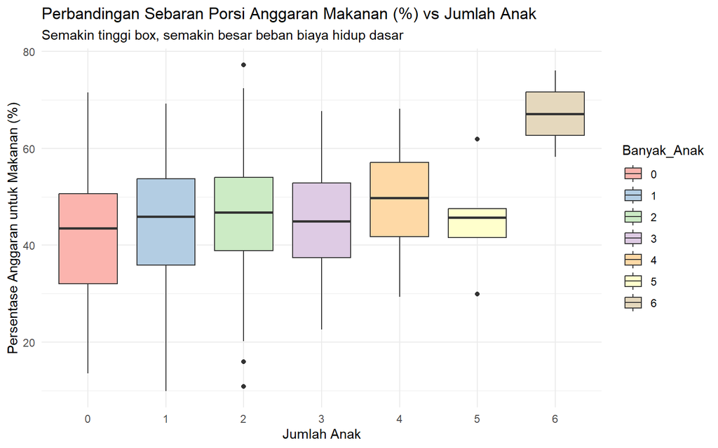

```r
df_insight <- data %>%
  filter(Banyak_Anak <= 6) %>%
  mutate(Food_Share = (FOOD / EXPEND) * 100,
         Banyak_Anak = as.factor(Banyak_Anak))
ggplot(df_insight, aes(x = Banyak_Anak, y = Food_Share, fill = Banyak_Anak)) +
  geom_boxplot() +
  scale_fill_brewer(palette = "Pastel1") +
  labs(title = "Perbandingan Sebaran Porsi Anggaran Makanan (%) vs Jumlah Anak",
       subtitle = "Semakin tinggi box, semakin besar beban biaya hidup dasar",
       x = "Jumlah Anak", y = "Persentase Anggaran untuk Makanan (%)") +
  theme_minimal()
```

# Sebaran Jumlah Anak dan Proporsi Kepemilikan Aset per Jumlah Anak

## Emas >= 10gram

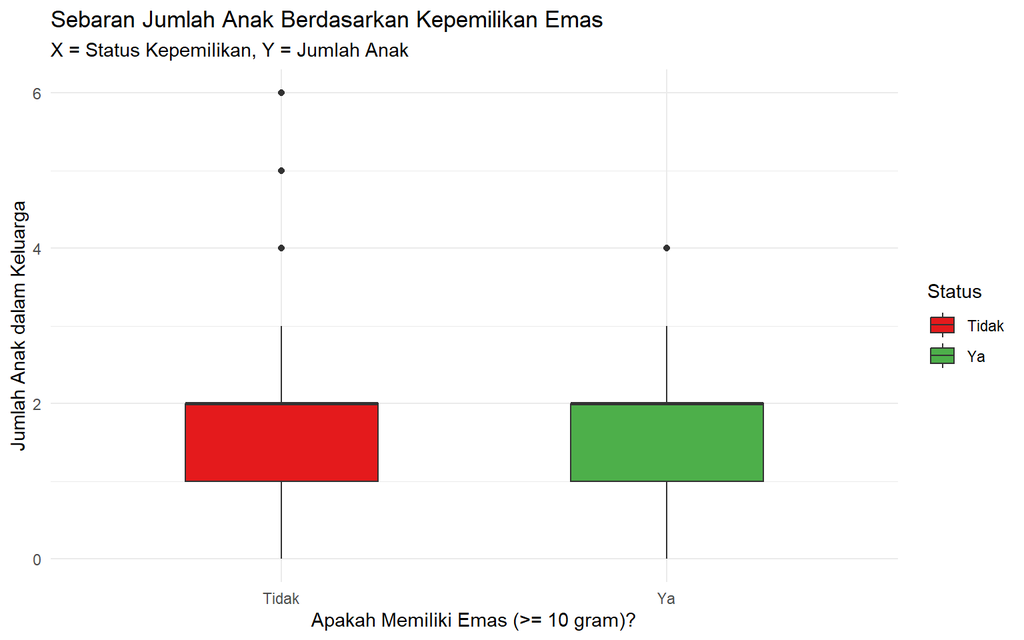

```r
# Boxplot
df_plot <- data %>%
  mutate(Status_Emas = ifelse(R2001G == 1, "Ya", "Tidak")) %>%
  filter(!is.na(Status_Emas))

ggplot(df_plot, aes(x = Status_Emas, y = Banyak_Anak, fill = Status_Emas)) +
  geom_boxplot(width = 0.5) +
  scale_fill_manual(values = c("Ya" = "#4DAF4A", "Tidak" = "#E41A1C")) +
  labs(title = "Sebaran Jumlah Anak Berdasarkan Kepemilikan Emas",
       subtitle = "X = Status Kepemilikan, Y = Jumlah Anak",
       x = "Apakah Memiliki Emas (>= 10 gram)?",
       y = "Jumlah Anak dalam Keluarga",
       fill = "Status") +
  theme_minimal()
```

```r
df_plot %>%
  group_by(Status_Emas) %>%
  summarise(
    Rata_rata_Anak = mean(Banyak_Anak, na.rm = TRUE),
    Median_Anak = median(Banyak_Anak, na.rm = TRUE),
    Jumlah_Sampel = n()
  )
```

```
## # A tibble: 2 × 4
##   Status_Emas Rata_rata_Anak Median_Anak Jumlah_Sampel
##   <chr>                <dbl>       <dbl>         <int>
## 1 Tidak                 1.52           2           733
## 2 Ya                    1.56           2           304
```

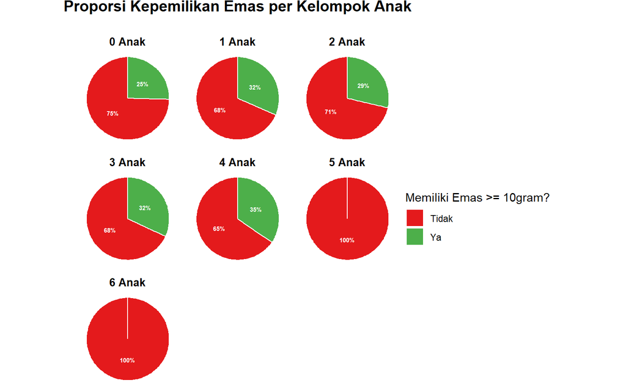

```r
df_emas_pie <- data %>%
  filter(Banyak_Anak <= 6) %>%
  # Mengubah kode 1 menjadi "Ya" dan 5 menjadi "Tidak"
  mutate(Status_Emas = ifelse(R2001G == 1, "Ya", "Tidak"),
         Banyak_Anak_Label = paste(Banyak_Anak, "Anak")) %>%
  filter(!is.na(Status_Emas)) %>%
  # Hitung jumlah per kelompok
  group_by(Banyak_Anak_Label, Status_Emas) %>%
  summarise(Total = n(), .groups = 'drop') %>%
  # Hitung persentase per kelompok anak
  group_by(Banyak_Anak_Label) %>%
  mutate(Proporsi = Total / sum(Total),
         Label_Persen = paste0(round(Proporsi * 100, 0), "%"))

# Plotting Multi-Pie Chart
ggplot(df_emas_pie, aes(x = "", y = Total, fill = Status_Emas)) +
  geom_bar(stat = "identity", width = 1, color = "white", position = position_fill()) +
  coord_polar("y", start = 0) +
  facet_wrap(~Banyak_Anak_Label, ncol = 3) +

  geom_text(aes(label = Label_Persen),
            position = position_fill(vjust = 0.5),
            size = 2,
            color = "white", fontface = "bold") +

  scale_fill_manual(values = c("Ya" = "#4DAF4A", "Tidak" = "#E41A1C")) +

  theme_void() +
  theme(strip.text = element_text(size = 10, face = "bold"),
        legend.position = "right",
        plot.title = element_text(size = 14, face = "bold", hjust = 0.5, margin = margin(b = 20))) +

  labs(title = "Proporsi Kepemilikan Emas per Kelompok Anak",
       fill = "Memiliki Emas >= 10gram?")
```

Secara keseluruhan, tidak terdapat perbedaan signifikan pada jumlah anak antara keluarga yang memiliki emas dan yang tidak memiliki emas. Perbedaan kecil hanya terlihat pada pencilan (outliers), di mana kelompok yang tidak memiliki emas memiliki variasi jumlah anak yang lebih ekstrem ke atas (hingga 6 anak), sedangkan kelompok yang memiliki emas memiliki pencilan yang lebih rendah (hingga 4 anak). Jika kita lihat dari proporsi kepemilikannya, terdapat ambang batas kemampuan finansial yang nyata. Ketika jumlah anak mencapai 5 atau lebih, kapasitas keluarga untuk memiliki aset investasi (emas $\ge$ 10 gram) hilang sepenuhnya, kemungkinan besar karena seluruh pendapatan dialihkan untuk biaya hidup dasar yang sangat tinggi.

## Motor

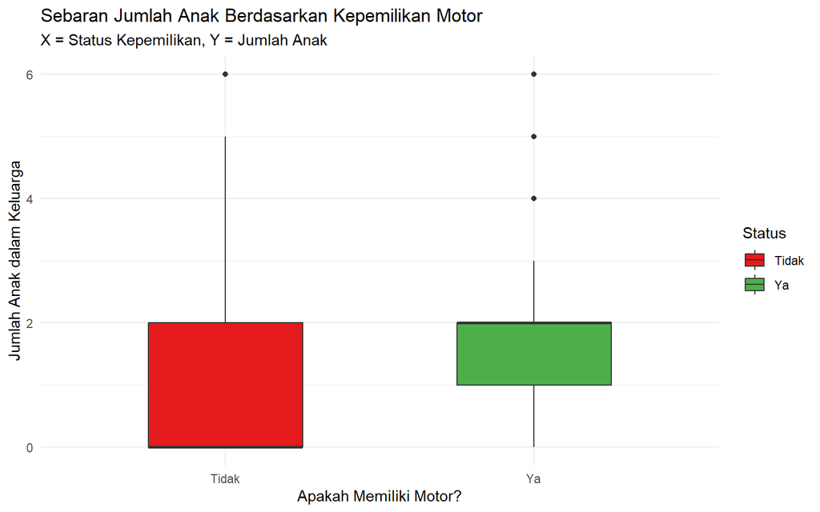

```r
# Boxplot
df_plot <- data %>%
  mutate(Status_Emas = ifelse(R2001H == 1, "Ya", "Tidak")) %>%
  filter(!is.na(Status_Emas))

ggplot(df_plot, aes(x = Status_Emas, y = Banyak_Anak, fill = Status_Emas)) +
  geom_boxplot(width = 0.5) +
  scale_fill_manual(values = c("Ya" = "#4DAF4A", "Tidak" = "#E41A1C")) +
  labs(title = "Sebaran Jumlah Anak Berdasarkan Kepemilikan Motor",
       subtitle = "X = Status Kepemilikan, Y = Jumlah Anak",
       x = "Apakah Memiliki Motor?",
       y = "Jumlah Anak dalam Keluarga",
       fill = "Status") +
  theme_minimal()
```

```r
df_plot %>%
  group_by(Status_Emas) %>%
  summarise(
    Rata_rata_Anak = mean(Banyak_Anak, na.rm = TRUE),
    Median_Anak = median(Banyak_Anak, na.rm = TRUE),
    Jumlah_Sampel = n()
  )
```

```
## # A tibble: 2 × 4
##   Status_Emas Rata_rata_Anak Median_Anak Jumlah_Sampel
##   <chr>                <dbl>       <dbl>         <int>
## 1 Tidak                0.935           0           170
## 2 Ya                   1.65            2           867
```

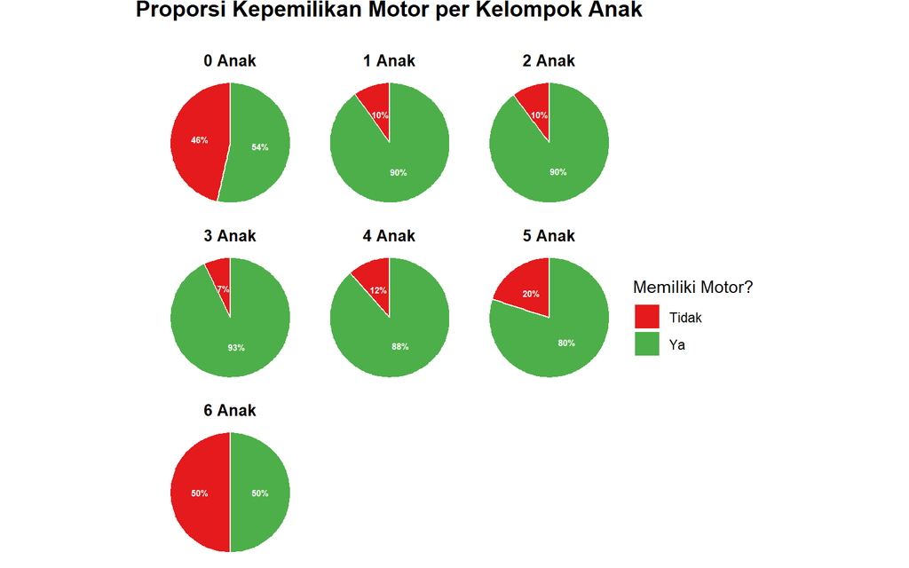

```r
df_emas_pie <- data %>%
  filter(Banyak_Anak <= 6) %>%
  # Mengubah kode 1 menjadi "Ya" dan 5 menjadi "Tidak"
  mutate(Status_Emas = ifelse(R2001H == 1, "Ya", "Tidak"),
         Banyak_Anak_Label = paste(Banyak_Anak, "Anak")) %>%
  filter(!is.na(Status_Emas)) %>%
  # Hitung jumlah per kelompok
  group_by(Banyak_Anak_Label, Status_Emas) %>%
  summarise(Total = n(), .groups = 'drop') %>%
  # Hitung persentase per kelompok anak
  group_by(Banyak_Anak_Label) %>%
  mutate(Proporsi = Total / sum(Total),
         Label_Persen = paste0(round(Proporsi * 100, 0), "%"))

# Plotting Multi-Pie Chart
ggplot(df_emas_pie, aes(x = "", y = Total, fill = Status_Emas)) +
  geom_bar(stat = "identity", width = 1, color = "white", position = position_fill()) +
  coord_polar("y", start = 0) +
  facet_wrap(~Banyak_Anak_Label, ncol = 3) +

  geom_text(aes(label = Label_Persen),
            position = position_fill(vjust = 0.5),
            size = 2,
            color = "white", fontface = "bold") +

  scale_fill_manual(values = c("Ya" = "#4DAF4A", "Tidak" = "#E41A1C")) +

  theme_void() +
  theme(strip.text = element_text(size = 10, face = "bold"),
        legend.position = "right",
        plot.title = element_text(size = 14, face = "bold", hjust = 0.5, margin = margin(b = 20))) +

  labs(title = "Proporsi Kepemilikan Motor per Kelompok Anak",
       fill = "Memiliki Motor?")
```

## Mobil

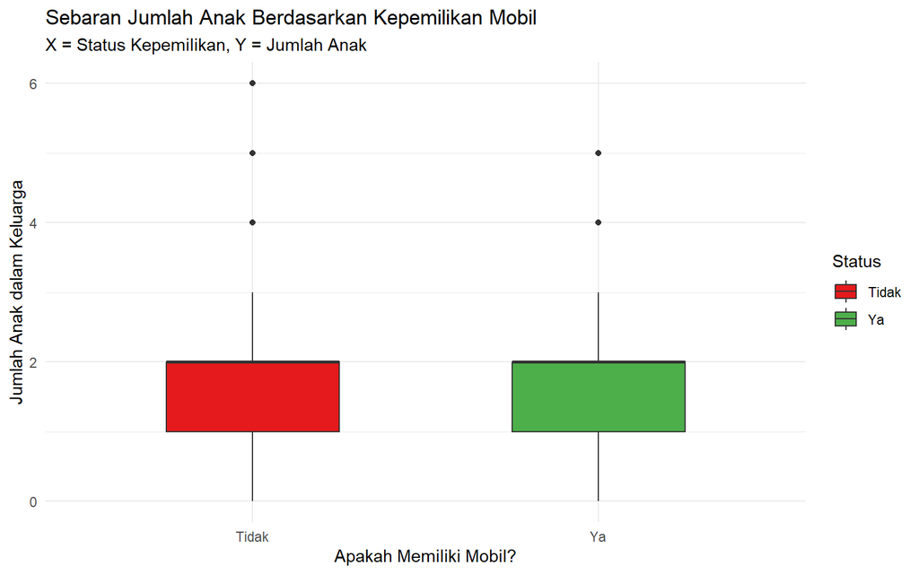

```r
# Boxplot
df_plot <- data %>%
  mutate(Status_Emas = ifelse(R2001K == 1, "Ya", "Tidak")) %>%
  filter(!is.na(Status_Emas))

ggplot(df_plot, aes(x = Status_Emas, y = Banyak_Anak, fill = Status_Emas)) +
  geom_boxplot(width = 0.5) +
  scale_fill_manual(values = c("Ya" = "#4DAF4A", "Tidak" = "#E41A1C")) +
  labs(title = "Sebaran Jumlah Anak Berdasarkan Kepemilikan Mobil",
       subtitle = "X = Status Kepemilikan, Y = Jumlah Anak",
       x = "Apakah Memiliki Mobil?",
       y = "Jumlah Anak dalam Keluarga",
       fill = "Status") +
  theme_minimal()
```

```r
df_plot %>%
  group_by(Status_Emas) %>%
  summarise(
    Rata_rata_Anak = mean(Banyak_Anak, na.rm = TRUE),
    Median_Anak = median(Banyak_Anak, na.rm = TRUE),
    Jumlah_Sampel = n()
  )
```

```
## # A tibble: 2 × 4
##   Status_Emas Rata_rata_Anak Median_Anak Jumlah_Sampel
##   <chr>                <dbl>       <dbl>         <int>
## 1 Tidak                 1.50           2           825
## 2 Ya                    1.67           2           212
```

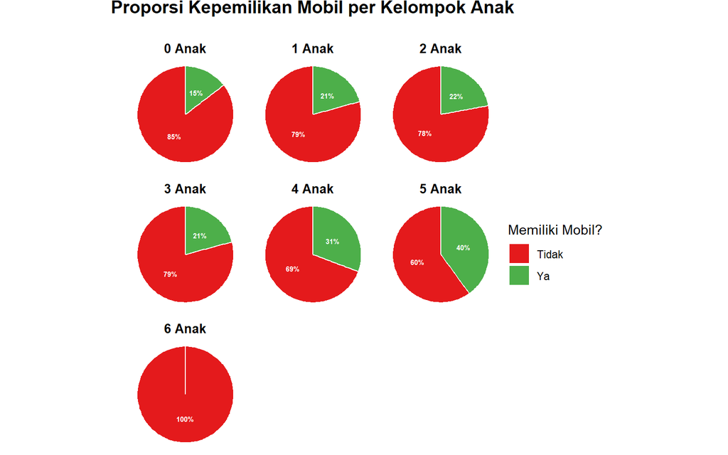

```r
df_emas_pie <- data %>%
  filter(Banyak_Anak <= 6) %>%
  # Mengubah kode 1 menjadi "Ya" dan 5 menjadi "Tidak"
  mutate(Status_Emas = ifelse(R2001K == 1, "Ya", "Tidak"),
         Banyak_Anak_Label = paste(Banyak_Anak, "Anak")) %>%
  filter(!is.na(Status_Emas)) %>%
  # Hitung jumlah per kelompok
  group_by(Banyak_Anak_Label, Status_Emas) %>%
  summarise(Total = n(), .groups = 'drop') %>%
  # Hitung persentase per kelompok anak
  group_by(Banyak_Anak_Label) %>%
  mutate(Proporsi = Total / sum(Total),
         Label_Persen = paste0(round(Proporsi * 100, 0), "%"))

# Plotting Multi-Pie Chart
ggplot(df_emas_pie, aes(x = "", y = Total, fill = Status_Emas)) +
  geom_bar(stat = "identity", width = 1, color = "white", position = position_fill()) +
  coord_polar("y", start = 0) +
  facet_wrap(~Banyak_Anak_Label, ncol = 3) +

  geom_text(aes(label = Label_Persen),
            position = position_fill(vjust = 0.5),
            size = 2,
            color = "white", fontface = "bold") +

  scale_fill_manual(values = c("Ya" = "#4DAF4A", "Tidak" = "#E41A1C")) +

  theme_void() +
  theme(strip.text = element_text(size = 10, face = "bold"),
        legend.position = "right",
        plot.title = element_text(size = 14, face = "bold", hjust = 0.5, margin = margin(b = 20))) +

  labs(title = "Proporsi Kepemilikan Mobil per Kelompok Anak",
       fill = "Memiliki Mobil?")
```

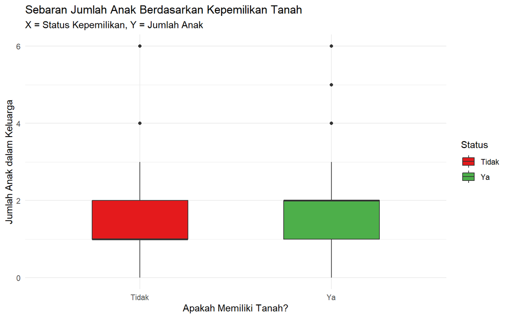

```r
# Boxplot
df_plot <- data %>%
  mutate(Status_Emas = ifelse(R2001M == 1, "Ya", "Tidak")) %>%
  filter(!is.na(Status_Emas))

ggplot(df_plot, aes(x = Status_Emas, y = Banyak_Anak, fill = Status_Emas)) +
  geom_boxplot(width = 0.5) +
  scale_fill_manual(values = c("Ya" = "#4DAF4A", "Tidak" = "#E41A1C")) +
  labs(title = "Sebaran Jumlah Anak Berdasarkan Kepemilikan Tanah",
       subtitle = "X = Status Kepemilikan, Y = Jumlah Anak",
       x = "Apakah Memiliki Tanah?",
       y = "Jumlah Anak dalam Keluarga",
       fill = "Status") +
  theme_minimal()
```

```r
df_plot %>%
  group_by(Status_Emas) %>%
  summarise(
    Rata_rata_Anak = mean(Banyak_Anak, na.rm = TRUE),
    Median_Anak = median(Banyak_Anak, na.rm = TRUE),
    Jumlah_Sampel = n()
  )
```

```
## # A tibble: 2 × 4
##   Status_Emas Rata_rata_Anak Median_Anak Jumlah_Sampel
##   <chr>                <dbl>       <dbl>         <int>
## 1 Tidak                 1.44           1           269
## 2 Ya                    1.57           2           768
```

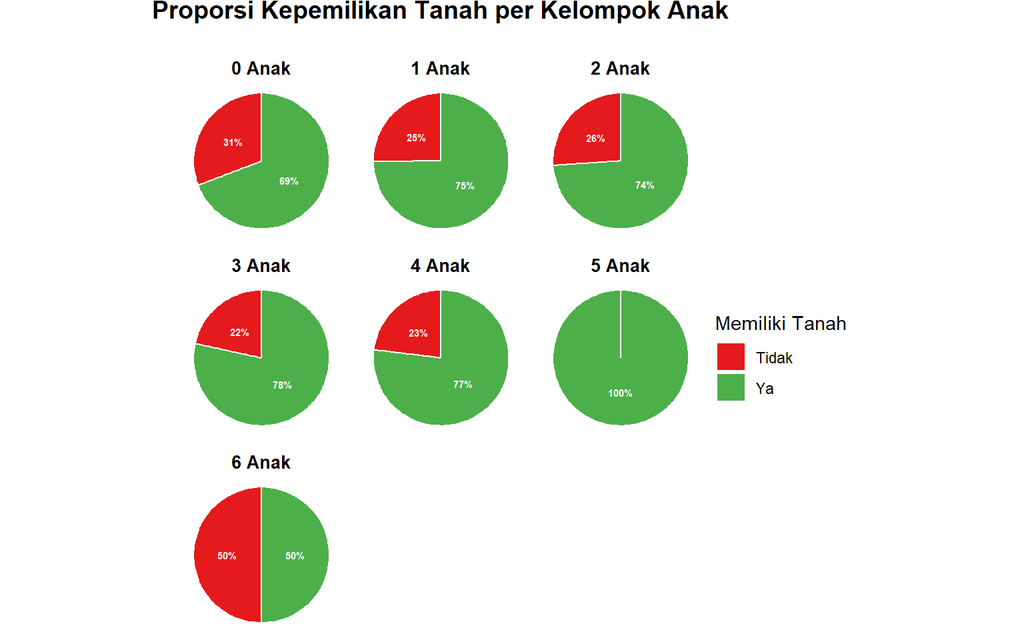

```r
df_emas_pie <- data %>%
  filter(Banyak_Anak <= 6) %>%
  # Mengubah kode 1 menjadi "Ya" dan 5 menjadi "Tidak"
  mutate(Status_Emas = ifelse(R2001M == 1, "Ya", "Tidak"),
         Banyak_Anak_Label = paste(Banyak_Anak, "Anak")) %>%
  filter(!is.na(Status_Emas)) %>%
  # Hitung jumlah per kelompok
  group_by(Banyak_Anak_Label, Status_Emas) %>%
  summarise(Total = n(), .groups = 'drop') %>%
  # Hitung persentase per kelompok anak
  group_by(Banyak_Anak_Label) %>%
  mutate(Proporsi = Total / sum(Total),
         Label_Persen = paste0(round(Proporsi * 100, 0), "%"))

# Plotting Multi-Pie Chart
ggplot(df_emas_pie, aes(x = "", y = Total, fill = Status_Emas)) +
  geom_bar(stat = "identity", width = 1, color = "white", position = position_fill()) +
  coord_polar("y", start = 0) +
  facet_wrap(~Banyak_Anak_Label, ncol = 3) +

  geom_text(aes(label = Label_Persen),
            position = position_fill(vjust = 0.5),
            size = 2,
            color = "white", fontface = "bold") +

  scale_fill_manual(values = c("Ya" = "#4DAF4A", "Tidak" = "#E41A1C")) +

  theme_void() +
  theme(strip.text = element_text(size = 10, face = "bold"),
        legend.position = "right",
        plot.title = element_text(size = 14, face = "bold", hjust = 0.5, margin = margin(b = 20))) +

  labs(title = "Proporsi Kepemilikan Tanah per Kelompok Anak",
       fill = "Memiliki Tanah")
```

# EXPLAIN

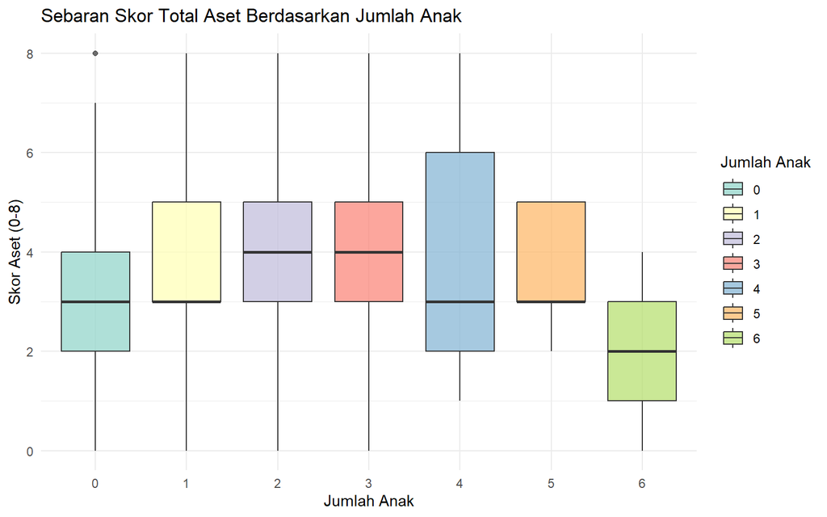

```r
# Pemetaan Kode Aset ke Nama yang Jelas
asset_map <- c(
  "R2001B" = "Kulkas",
  "R2001C" = "AC",
  "R2001D" = "Water Heater",
  "R2001F" = "Komputer",
  "R2001G" = "Emas",
  "R2001H" = "Motor",
  "R2001K" = "Mobil",
  "R2001M" = "Tanah"
)

# Pre-processing dasar: Mengubah 1 (Ya) dan 5 (Tidak) menjadi 1 dan 0
df_clean <- data %>%
  mutate(across(all_of(names(asset_map)), ~ ifelse(. == 1, 1, 0))) %>%
  mutate(Total_Asset_Score = rowSums(select(., all_of(names(asset_map))))) %>%
  mutate(Food_Share = (FOOD / EXPEND) * 100) %>%
  filter(Banyak_Anak <= 6) # Fokus pada keluarga dengan 0-6 anak

# ANALISIS 1: SEBARAN TOTAL SKOR ASET (BOXPLOT)
# Melihat total kepemilikan aset berdasarkan kelompok anak
p1 <- ggplot(df_clean, aes(x = as.factor(Banyak_Anak), y = Total_Asset_Score, fill = as.factor(Banyak_Anak))) +
  geom_boxplot(alpha = 0.7) +
  scale_fill_brewer(palette = "Set3") +
  labs(title = "Sebaran Skor Total Aset Berdasarkan Jumlah Anak",
       x = "Jumlah Anak", y = "Skor Aset (0-8)", fill = "Jumlah Anak") +
  theme_minimal()

print(p1)
```

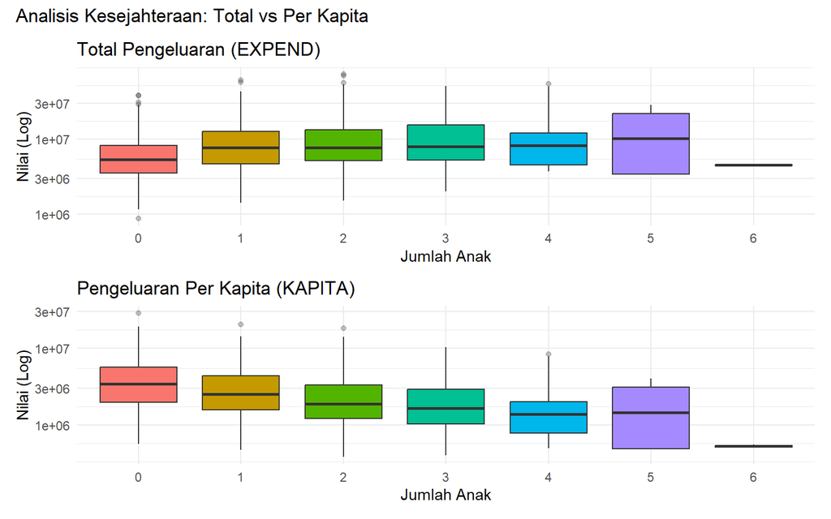

```r
# ANALISIS 2: "BANYAK ANAK BANYAK REZEKI?" (EXPEND vs KAPITA)
# Membandingkan Total Rezeki Rumah Tangga vs Rezeki per Orang
p_expend <- ggplot(df_clean, aes(x = as.factor(Banyak_Anak), y = EXPEND, fill = as.factor(Banyak_Anak))) +
  geom_boxplot(outlier.alpha = 0.3) + scale_y_log10() +
  labs(title = "Total Pengeluaran (EXPEND)", x = "Jumlah Anak", y = "Nilai (Log)") +
  theme_minimal() + guides(fill = "none")

p_kapita <- ggplot(df_clean, aes(x = as.factor(Banyak_Anak), y = KAPITA, fill = as.factor(Banyak_Anak))) +
  geom_boxplot(outlier.alpha = 0.3) + scale_y_log10() +
  labs(title = "Pengeluaran Per Kapita (KAPITA)", x = "Jumlah Anak", y = "Nilai (Log)") +
  theme_minimal() + guides(fill = "none")

# Menggabungkan dua grafik
(p_expend / p_kapita) + plot_annotation(title = "Analisis Kesejahteraan: Total vs Per Kapita")
```

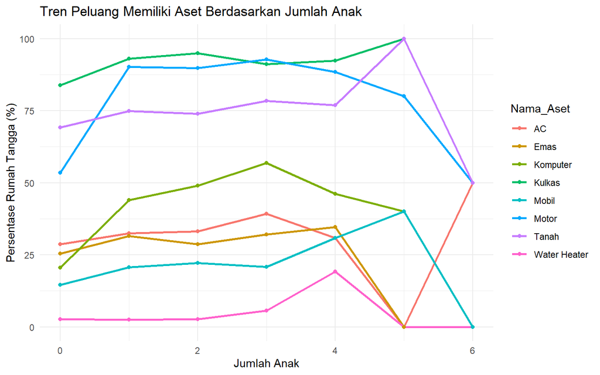

```r
# ANALISIS 3: TREN PELUANG KEPEMILIKAN ASET (LINE CHART)
df_trend <- df_clean %>%
  group_by(Banyak_Anak) %>%
  summarise(across(all_of(names(asset_map)), ~ mean(.) * 100)) %>%
  pivot_longer(cols = -Banyak_Anak, names_to = "Asset_Code", values_to = "Persen") %>%
  mutate(Nama_Aset = asset_map[Asset_Code])

ggplot(df_trend, aes(x = Banyak_Anak, y = Persen, color = Nama_Aset, group = Nama_Aset)) +
  geom_line(size = 1) + geom_point() +
  labs(title = "Tren Peluang Memiliki Aset Berdasarkan Jumlah Anak",
       x = "Jumlah Anak", y = "Persentase Rumah Tangga (%)") +
  theme_minimal()
```

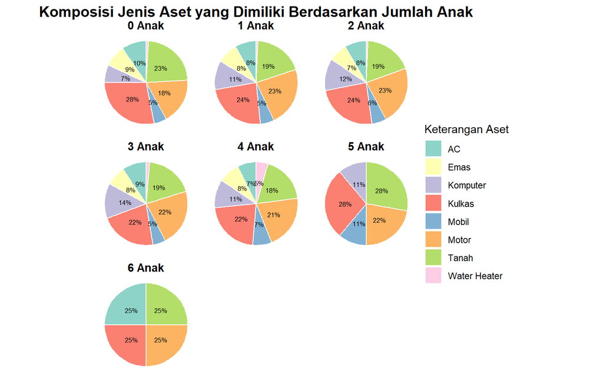

```r
# ANALISIS 4: PIE CHART PORTOFOLIO ASET (DENGAN LABEL KECIL)
df_pie <- df_clean %>%
  group_by(Banyak_Anak) %>%
  summarise(across(all_of(names(asset_map)), sum)) %>%
  pivot_longer(cols = -Banyak_Anak, names_to = "Asset_Code", values_to = "Total") %>%
  mutate(Nama_Aset = asset_map[Asset_Code],
         Banyak_Anak_Label = paste(Banyak_Anak, "Anak")) %>%
  filter(Total > 0) %>%
  group_by(Banyak_Anak) %>%
  mutate(Proporsi = Total / sum(Total),
         # Label hanya muncul jika > 3%, dibulatkan, ukuran kecil
         Label_Persen = ifelse(Proporsi > 0.03, paste0(round(Proporsi * 100, 0), "%"), ""))

ggplot(df_pie, aes(x = "", y = Total, fill = Nama_Aset)) +
  geom_bar(stat = "identity", width = 1, color = "white", position = position_fill()) +
  coord_polar("y", start = 0) +
  facet_wrap(~Banyak_Anak_Label, ncol = 3) +
  # Teks Persentase Kecil
  geom_text(aes(label = Label_Persen),
            position = position_fill(vjust = 0.5),
            size = 2.2, color = "black") +
  scale_fill_brewer(palette = "Set3") +
  theme_void() +
  theme(legend.position = "right",
        strip.text = element_text(size = 11, face = "bold"),
        plot.title = element_text(size = 14, face = "bold", hjust = 0.5)) +
  labs(title = "Komposisi Jenis Aset yang Dimiliki Berdasarkan Jumlah Anak",
       fill = "Keterangan Aset")
```

```r
# RINGKASAN STATISTIK
summary_table <- df_clean %>%
  group_by(Banyak_Anak) %>%
  summarise(
    Rerata_KAPITA = mean(KAPITA),
    Median_KAPITA = median(KAPITA),
    Porsi_Makan_Persen = mean(Food_Share),
    Total_Sampel = n()
  )

print("Ringkasan Kesejahteraan per Kelompok Anak:")
```

```
## [1] "Ringkasan Kesejahteraan per Kelompok Anak:"
```

```r
print(summary_table)
```

```
## # A tibble: 7 × 5
##   Banyak_Anak Rerata_KAPITA Median_KAPITA Porsi_Makan_Persen Total_Sampel
##         <dbl>         <dbl>         <dbl>              <dbl>        <int>
## 1           0      4431425.      3428702.               42.0          185
## 2           1      3355945.      2512938.               44.7          314
## 3           2      2615788.      1891374.               46.2          380
## 4           3      2355390.      1648457.               45.4          125
## 5           4      2251972.      1382780.               49.4           26
## 6           5      1927787.      1451111.               45.3            5
## 7           6       533416.       533416.               67.2            2
```

Berdasarkan grafik boxplot (Total Aset) tersebut, terlihat bahwa skor total aset bervariasi bergantung pada jumlah anak, di mana keluarga dengan 2 dan 3 anak memiliki median skor aset tertinggi, yakni di angka 4. Sementara itu, kelompok keluarga dengan 4 anak menunjukkan variasi skor aset yang paling lebar, menandakan ketimpangan aset yang lebih tinggi di dalam kelompok tersebut. Terdapat indikasi tren penurunan kepemilikan aset pada keluarga dengan jumlah anak yang banyak, terlihat jelas pada keluarga dengan 6 anak yang mencatatkan median skor aset terendah di angka 2 serta sebaran data yang mengelompok di nilai-nilai rendah. Selain itu, ditemukan juga satu kasus pencilan berupa keluarga tanpa anak yang memiliki skor aset maksimal, yaitu 8.

Berdasarkan grafik Total Pengeluaran (EXPEND), terlihat bahwa nilai tengah (median) pengeluaran rumah tangga cenderung stabil atau sedikit meningkat seiring bertambahnya jumlah anak dari 0 hingga 5. Hal ini merupakan kondisi yang wajar karena keluarga dengan jumlah anggota yang lebih besar secara otomatis membutuhkan biaya hidup keseluruhan yang lebih tinggi untuk memenuhi kebutuhan dasar. Meskipun demikian, sebaran data yang lebar serta adanya titik-titik pencilan (outliers) menunjukkan bahwa terdapat variasi pengeluaran yang cukup tinggi antar keluarga dengan jumlah anak yang sama.

Sebaliknya, grafik Pengeluaran Per Kapita memperlihatkan tren penurunan yang sangat jelas dan konsisten seiring dengan bertambahnya jumlah anak. Meskipun total pengeluaran keluarga membesar pada grafik EXPEND, grafik ini membuktikan bahwa “porsi” atau alokasi pengeluaran untuk masing-masing individu di dalam keluarga justru semakin mengecil saat jumlah anak bertambah. Fenomena ini menunjukkan adanya dilusi kesejahteraan ekonomi, di mana keluarga tanpa anak atau dengan anak yang lebih sedikit menikmati tingkat daya beli dan alokasi sumber daya per individu yang lebih tinggi dibandingkan dengan keluarga besar.

# Uji Non-Parametrik

## Uji Kruskal-Wallis dan Dunn Post-Hoc

```r
df_test <- data %>%
  filter(Banyak_Anak %in% c(0, 1, 2, 3, 4, 5, 6)) %>%
  mutate(Banyak_Anak = as.factor(Banyak_Anak))

# Jalankan Uji Kruskal-Wallis
ks_result <- kruskal.test(KAPITA ~ Banyak_Anak, data = df_test)
print(ks_result)
```

```
##
##  Kruskal-Wallis rank sum test
##
## data:  KAPITA by Banyak_Anak
## Kruskal-Wallis chi-squared = 107.72, df = 6, p-value < 2.2e-16
```

```r
# Jika hasil signifikan (p < 0.05), lakukan Uji Dunn (Post-Hoc)
# Ini untuk melihat kelompok mana yang benar-benar berbeda satu sama lain
if(ks_result$p.value < 0.05) {
  cat("\nHasil Signifikan. Melakukan Uji Lanjut (Dunn's Test)...\n")
  posthoc <- dunnTest(KAPITA ~ Banyak_Anak, data = df_test, method = "bh") # Benjamini-Hochberg adjustment
  print(posthoc)
}
```

```
##
## Hasil Signifikan. Melakukan Uji Lanjut (Dunn's Test)...
```

```
##   Kruskal-Wallis rank sum test
##
## data: x and g
## Kruskal-Wallis chi-squared = 107.7209, df = 6, p-value = 0
##
##
##                      Dunn's Pairwise Comparison of x by g
##                              (Benjamini-Hochberg)
## Col Mean-│
## Row Mean │          0          1          2          3          4          5
## ─────────┼──────────────────────────────────────────────────────────────────
##        1 │   3.953602
##          │     0.0003*
##          │
##        2 │   8.056358   4.665531
##          │     0.0000*    0.0000*
##          │
##        3 │   7.805169   5.080140   1.759774
##          │     0.0000*    0.0000*    0.1177
##          │
##        4 │   5.275301   3.618542   1.887561   0.933365
##          │     0.0000*    0.0009*    0.1034     0.4091
##          │
##        5 │   2.446594   1.647009   0.858812   0.449802   0.008099
##          │     0.0303*    0.1394     0.4315     0.6855     0.9935
##          │
##        6 │   3.110538   2.600825   2.100376   1.834669   1.507848   1.317742
##          │     0.0049*    0.0217*    0.0681     0.1075     0.1727     0.2317
##
## FDR = 0.05
## Reject Ho if p ≤ FDR with stopping rule, where p = Pr(|Z| ≥ |z|)
## Dunn (1964) Kruskal-Wallis multiple comparison
##
##   p-values adjusted with the Benjamini-Hochberg method.
```

```
##    Comparison           Z      P.unadj        P.adj
## 1       0 - 1 3.953602808 7.698316e-05 2.694411e-04
## 2       0 - 2 8.056358829 7.860068e-16 1.650614e-14
## 3       1 - 2 4.665531817 3.078199e-06 1.292843e-05
## 4       0 - 3 7.805169389 5.942168e-15 6.239276e-14
## 5       1 - 3 5.080140832 3.771552e-07 1.980065e-06
## 6       2 - 3 1.759774288 7.844608e-02 1.176691e-01
## 7       0 - 4 5.275301549 1.325380e-07 9.277658e-07
## 8       1 - 4 3.618542174 2.962672e-04 8.888017e-04
## 9       2 - 4 1.887561484 5.908484e-02 1.033985e-01
## 10      3 - 4 0.933365272 3.506314e-01 4.090700e-01
## 11      0 - 5 2.446594388 1.442130e-02 3.028474e-02
## 12      1 - 5 1.647009304 9.955613e-02 1.393786e-01
## 13      2 - 5 0.858812472 3.904440e-01 4.315434e-01
## 14      3 - 5 0.449802751 6.528527e-01 6.854953e-01
## 15      4 - 5 0.008099734 9.935374e-01 9.935374e-01
## 16      0 - 6 3.110538704 1.867464e-03 4.902094e-03
## 17      1 - 6 2.600825310 9.299980e-03 2.169995e-02
## 18      2 - 6 2.100376575 3.569573e-02 6.814639e-02
## 19      3 - 6 1.834669131 6.655473e-02 1.075115e-01
## 20      4 - 6 1.507848008 1.315934e-01 1.727164e-01
## 21      5 - 6 1.317742694 1.875898e-01 2.317286e-01
```

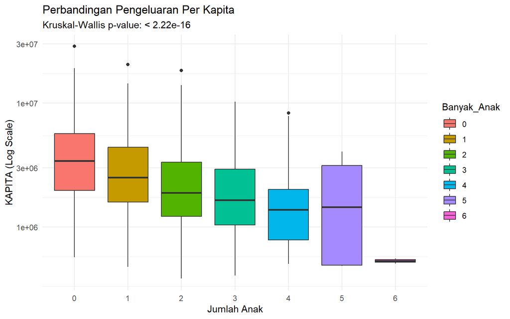

```r
# Visualisasi Boxplot untuk memperkuat hasil uji
library(ggplot2)
ggplot(df_test, aes(x = Banyak_Anak, y = KAPITA, fill = Banyak_Anak)) +
  geom_boxplot() +
  scale_y_log10() +
  theme_minimal() +
  labs(title = "Perbandingan Pengeluaran Per Kapita",
       subtitle = paste("Kruskal-Wallis p-value:", format.pval(ks_result$p.value)),
       x = "Jumlah Anak", y = "KAPITA (Log Scale)")
```

Hasil uji Kruskal-Wallis mengonfirmasi bahwa jumlah anak berpengaruh signifikan terhadap pengeluaran per kapita keluarga ($p < 0,001$). Uji lanjut Dunn menunjukkan bahwa terdapat perbedaan paling kontras pada masa transisi dari keluarga kecil (0-1 anak) ke keluarga menengah (2 anak atau lebih). Menariknya, setelah sebuah keluarga memiliki 2 anak, penambahan ke anak ke-3 dan ke-4 tidak menunjukkan penurunan kesejahteraan yang sedrastis transisi sebelumnya (p > 0,05). Hal ini mengindikasikan bahwa tekanan ekonomi terbesar pada ‘rezeki per kapita’ terjadi saat perpindahan dari memiliki 1 anak menjadi 2 anak, yang kemudian cenderung stabil namun tetap berada di level yang lebih rendah pada jumlah anak berikutnya

## Uji Spearman

```r
# 1. Korelasi Spearman
cor_kapita <- cor.test(data$Banyak_Anak, data$KAPITA, method = "spearman")
cor_expend <- cor.test(data$Banyak_Anak, data$EXPEND, method = "spearman")
print(paste("Anak vs KAPITA: rho =", round(cor_kapita$estimate, 3), ", p =", cor_kapita$p.value))
```

```
## [1] "Anak vs KAPITA: rho = -0.316 , p = 1.97943790559413e-25"
```

```r
print(paste("Anak vs EXPEND: rho =", round(cor_expend$estimate, 3), ", p =", cor_expend$p.value))
```

```
## [1] "Anak vs EXPEND: rho = 0.185 , p = 2.14533810128417e-09"
```

Terdapat korelasi yang negatif dan signifikan secara statistik antara jumlah anak dengan pengeluaran per kapita. Tanda negatif (-) menandakan hubungan terbalik: semakin banyak jumlah anak dalam suatu keluarga, maka pengeluaran per kapita (jatah per orang) cenderung semakin menurun. Kekuatan korelasi sebesar 0.316 ini tergolong dalam kategori lemah hingga sedang. Hasil ini secara matematis mengonfirmasi fenomena “dilusi kesejahteraan”

Terdapat korelasi yang positif dan signifikan secara statistik antara jumlah anak dengan total pengeluaran rumah tangga. Tanda positif menandakan hubungan searah: semakin banyak anak, maka total pengeluaran keseluruhan keluarga tersebut cenderung meningkat. Namun, dengan nilai rho sebesar 0.185, kekuatan hubungan linier ini tergolong lemah.

## Uji Mann-Whitney U Test untuk TIAP Kategori Aset

```r
asset_map <- c(
  "R2001B" = "Kulkas", "R2001C" = "AC", "R2001D" = "Water Heater",
  "R2001F" = "Komputer", "R2001G" = "Emas", "R2001H" = "Motor",
  "R2001K" = "Mobil", "R2001M" = "Tanah"
)

hasil_mw <- lapply(names(asset_map), function(code) {
  # Uji Wilcoxon (Mann-Whitney)
  test <- wilcox.test(KAPITA ~ get(code), data = data)

  # Hitung Median
  med_ya <- median(data$KAPITA[data[[code]] == 1], na.rm = TRUE)
  med_tidak <- median(data$KAPITA[data[[code]] == 5], na.rm = TRUE)

  data.frame(
    Aset = asset_map[code],
    p_value = test$p.value,
    Signifikan = ifelse(test$p.value < 0.05, "Ya", "Tidak"),
    Median_Ya = round(med_ya),
    Median_Tidak = round(med_tidak)
  )
})

print(do.call(rbind, hasil_mw))
```

```
##                Aset      p_value Signifikan Median_Ya Median_Tidak
## R2001B       Kulkas 3.002097e-08         Ya   2266114      1387986
## R2001C           AC 8.281308e-61         Ya   4228865      1712510
## R2001D Water Heater 2.525298e-11         Ya   6445845      2126280
## R2001F     Komputer 1.720762e-42         Ya   3598563      1707282
## R2001G         Emas 1.014004e-43         Ya   4157971      1814972
## R2001H        Motor 3.416253e-01      Tidak   2230940      1961138
## R2001K        Mobil 1.056424e-47         Ya   5073435      1851583
## R2001M        Tanah 2.482807e-21         Ya   2629210      1565647
```

- Kulkas  
  Terdapat perbedaan kesejahteraan yang signifikan (p-value 3.00e-08). Keluarga yang memiliki kulkas terbukti memiliki tingkat ekonomi yang lebih tinggi dengan median 2.266.114 dibandingkan yang tidak memilikinya (1.387.986).
- AC  
  Didapatkan hasil yang sangat signifikan (p-value 8.28e-61). Kepemilikan AC merupakan indikator pembeda status ekonomi yang kuat. Keluarga dengan AC memiliki median kesejahteraan (4.228.865) yang melesat jauh lebih dari dua kali lipat dibanding keluarga tanpa AC (1.712.510).
- Water Heater  
  Perbedaan ini sangat signifikan (p-value 2.52e-11). Aset ini menunjukkan jurang pemisah ekonomi paling mencolok (gap tertinggi). Median kelompok pemilik mencapai angka tertinggi, yakni 6.445.845, dibanding yang tidak memiliki (2.126.280). Ini menandakan water heater adalah aset tersier/mewah pada sampel ini.
- Komputer  
  Perbedaan bernilai signifikan (p-value 1.72e-42). Keluarga dengan komputer memiliki tingkat ekonomi yang secara nyata lebih tinggi (median 3.598.563) dibandingkan keluarga tanpa komputer (1.707.282)
- Emas  
  Hasilnya signifikan (p-value 1.01e-43). Sebagai aset simpanan/investasi, kepemilikan emas membedakan kelas ekonomi dengan jelas. Pemilik emas mencatatkan median 4.157.971, berbanding 1.814.972 untuk yang tidak memilikinya.
- Motor  
  Motor satu-satunya aset yang hasilnya TIDAK signifikan (p-value 0.341 > 0.05). Meskipun median pemilik motor (2.230.940) sedikit lebih tinggi dari yang tidak memiliki (1.961.138), secara statistik perbedaan ini dianggap tidak bermakna/hanya kebetulan. Hal ini sangat wajar terjadi karena sepeda motor kemungkinan besar sudah menjadi alat transportasi primer yang dimiliki secara merata oleh hampir semua lapisan status ekonomi dasar hingga atas.
- Mobil  
  Terdapat perbedaan yang sangat signifikan (p-value 1.05e-47). Mobil masih menjadi aset penentu stratifikasi kelas atas; median pemilik mobil menembus 5.073.435, sangat kontras dengan non-pemilik di angka 1.851.583.
- Tanah  
  Perbedaannya signifikan secara statistik (p-value 2.48e-21). Keluarga yang memiliki aset berupa tanah memiliki status ekonomi yang lebih baik (median 2.629.210) dibandingkan mereka yang tidak (1.565.647).